# Documentation

This is a small eg. of an interactive web app using shiny. R data set Titanic was used for calculating the chances of survival of an individual.

## Format

The variables and their levels are as follows:

0. No Name Levels
1. Class 1st, 2nd, 3rd, Crew
2. Sex Male, Female
3. Age Child, Adult
4. Survived No, Yes
5. Freq

## App I/O

The Class,Sex,Age are taken as user inputs and Freq(Yes)/(Freq(Yes)+Freq(No)) is displayed in percentage.

## Details

The sinking of the Titanic is a famous event, and new books are still being published about it. Many well-known facts—from the proportions of first-class passengers to the ‘women and children first’ policy, and the fact that that policy was not entirely successful in saving the women and children in the third class—are reflected in the survival rates for various classes of passenger.

These data were originally collected by the British Board of Trade in their investigation of the sinking. Note that there is not complete agreement among primary sources as to the exact numbers on board, rescued, or lost.

Due in particular to the very successful film ‘Titanic’, the last years saw a rise in public interest in the Titanic. Very detailed data about the passengers is now available on the Internet, at sites such as Encyclopedia Titanica (http://www.rmplc.co.uk/eduweb/sites/phind).

## Source

Dawson, Robert J. MacG. (1995), The ‘Unusual Episode’ Data Revisited. Journal of Statistics Education, 3. http://www.amstat.org/publications/jse/v3n3/datasets.dawson.html

The source provides a data set recording class, sex, age, and survival status for each person on board of the Titanic, and is based on data originally collected by the British Board of Trade and reprinted in:

British Board of Trade (1990), Report on the Loss of the ‘Titanic’ (S.S.). British Board of Trade Inquiry Report (reprint). Gloucester, UK: Allan Sutton Publishing.

# Summary

A breif summary and mosaicplot fo the dataset are given below.

```r
data(Titanic)
summary(Titanic)
```

```
## Number of cases in table: 2201
## Number of factors: 4
## Test for independence of all factors:
##  Chisq = 1637, df = 25, p-value = 0
##  Chi-squared approximation may be incorrect
```

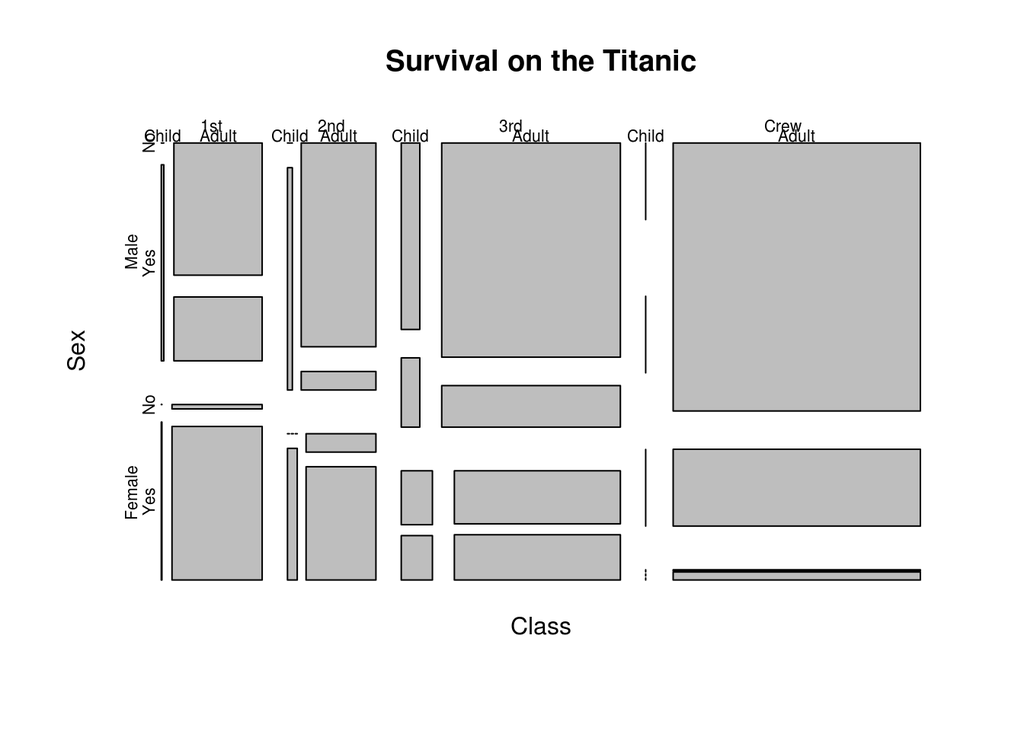

```r
require(graphics)
mosaicplot(Titanic, main = "Survival on the Titanic")
```